# Risk Factor Analysis

## Outcome Variable

**Outcome Variable:** haz

## Predictor Variables

**Intervention Variable:** predexfd6

**Adjustment Set:**

unadjusted

## Stratifying Variables

The analysis was stratified on these variable(s):

- agecat
- studyid
- country

## Data Summary

| agecat | studyid | country | predexfd6 | n_cell | n |
| --- | --- | --- | --- | --- | --- |
| Birth | ki0047075b-MAL-ED | BANGLADESH | 1 | 119 | 231 |
| Birth | ki0047075b-MAL-ED | BANGLADESH | 0 | 112 | 231 |
| Birth | ki0047075b-MAL-ED | BRAZIL | 1 | 27 | 175 |
| Birth | ki0047075b-MAL-ED | BRAZIL | 0 | 148 | 175 |
| Birth | ki0047075b-MAL-ED | INDIA | 1 | 15 | 190 |
| Birth | ki0047075b-MAL-ED | INDIA | 0 | 175 | 190 |
| Birth | ki0047075b-MAL-ED | NEPAL | 1 | 23 | 170 |
| Birth | ki0047075b-MAL-ED | NEPAL | 0 | 147 | 170 |
| Birth | ki0047075b-MAL-ED | PERU | 1 | 106 | 256 |
| Birth | ki0047075b-MAL-ED | PERU | 0 | 150 | 256 |
| Birth | ki0047075b-MAL-ED | SOUTH AFRICA | 1 | 3 | 211 |
| Birth | ki0047075b-MAL-ED | SOUTH AFRICA | 0 | 208 | 211 |
| Birth | ki0047075b-MAL-ED | TANZANIA, UNITED REPUBLIC OF | 1 | 1 | 119 |
| Birth | ki0047075b-MAL-ED | TANZANIA, UNITED REPUBLIC OF | 0 | 118 | 119 |
| Birth | ki1000108-CMC-V-BCS-2002 | INDIA | 1 | 7 | 7 |
| Birth | ki1000108-CMC-V-BCS-2002 | INDIA | 0 | 0 | 7 |
| Birth | ki1000108-IRC | INDIA | 1 | 0 | 14 |
| Birth | ki1000108-IRC | INDIA | 0 | 14 | 14 |
| Birth | ki1000109-EE | PAKISTAN | 1 | 1 | 2 |
| Birth | ki1000109-EE | PAKISTAN | 0 | 1 | 2 |
| Birth | ki1000304b-SAS-CompFeed | INDIA | 1 | 48 | 50 |
| Birth | ki1000304b-SAS-CompFeed | INDIA | 0 | 2 | 50 |
| Birth | ki1101329-Keneba | GAMBIA | 1 | 484 | 1401 |
| Birth | ki1101329-Keneba | GAMBIA | 0 | 917 | 1401 |
| Birth | kiGH5241-JiVitA-3 | BANGLADESH | 1 | 15096 | 19082 |
| Birth | kiGH5241-JiVitA-3 | BANGLADESH | 0 | 3986 | 19082 |
| Birth | kiGH5241-JiVitA-4 | BANGLADESH | 1 | 619 | 767 |
| Birth | kiGH5241-JiVitA-4 | BANGLADESH | 0 | 148 | 767 |
| 6 months | ki0047075b-MAL-ED | BANGLADESH | 1 | 123 | 235 |
| 6 months | ki0047075b-MAL-ED | BANGLADESH | 0 | 112 | 235 |

[output cut: 64 more lines]

The following strata were considered:

- agecat: 24 months, studyid: ki0047075b-MAL-ED, country: BANGLADESH
- agecat: 24 months, studyid: ki0047075b-MAL-ED, country: BRAZIL
- agecat: 24 months, studyid: ki0047075b-MAL-ED, country: INDIA
- agecat: 24 months, studyid: ki0047075b-MAL-ED, country: NEPAL
- agecat: 24 months, studyid: ki0047075b-MAL-ED, country: PERU
- agecat: 24 months, studyid: ki0047075b-MAL-ED, country: SOUTH AFRICA
- agecat: 24 months, studyid: ki0047075b-MAL-ED, country: TANZANIA, UNITED REPUBLIC OF
- agecat: 24 months, studyid: ki1000108-CMC-V-BCS-2002, country: INDIA
- agecat: 24 months, studyid: ki1000108-IRC, country: INDIA
- agecat: 24 months, studyid: ki1017093b-PROVIDE, country: BANGLADESH
- agecat: 24 months, studyid: ki1101329-Keneba, country: GAMBIA
- agecat: 24 months, studyid: ki1113344-GMS-Nepal, country: NEPAL
- agecat: 24 months, studyid: ki1148112-LCNI-5, country: MALAWI
- agecat: 24 months, studyid: kiGH5241-JiVitA-3, country: BANGLADESH
- agecat: 24 months, studyid: kiGH5241-JiVitA-4, country: BANGLADESH
- agecat: 6 months, studyid: ki0047075b-MAL-ED, country: BANGLADESH
- agecat: 6 months, studyid: ki0047075b-MAL-ED, country: BRAZIL
- agecat: 6 months, studyid: ki0047075b-MAL-ED, country: INDIA
- agecat: 6 months, studyid: ki0047075b-MAL-ED, country: NEPAL
- agecat: 6 months, studyid: ki0047075b-MAL-ED, country: PERU
- agecat: 6 months, studyid: ki0047075b-MAL-ED, country: SOUTH AFRICA
- agecat: 6 months, studyid: ki0047075b-MAL-ED, country: TANZANIA, UNITED REPUBLIC OF
- agecat: 6 months, studyid: ki1000108-CMC-V-BCS-2002, country: INDIA
- agecat: 6 months, studyid: ki1000108-IRC, country: INDIA
- agecat: 6 months, studyid: ki1000109-EE, country: PAKISTAN
- agecat: 6 months, studyid: ki1000304b-SAS-CompFeed, country: INDIA
- agecat: 6 months, studyid: ki1000304b-SAS-FoodSuppl, country: INDIA
- agecat: 6 months, studyid: ki1017093b-PROVIDE, country: BANGLADESH
- agecat: 6 months, studyid: ki1101329-Keneba, country: GAMBIA
- agecat: 6 months, studyid: ki1113344-GMS-Nepal, country: NEPAL
- agecat: 6 months, studyid: ki1148112-LCNI-5, country: MALAWI
- agecat: 6 months, studyid: kiGH5241-JiVitA-3, country: BANGLADESH
- agecat: 6 months, studyid: kiGH5241-JiVitA-4, country: BANGLADESH
- agecat: Birth, studyid: ki0047075b-MAL-ED, country: BANGLADESH
- agecat: Birth, studyid: ki0047075b-MAL-ED, country: BRAZIL
- agecat: Birth, studyid: ki0047075b-MAL-ED, country: INDIA
- agecat: Birth, studyid: ki0047075b-MAL-ED, country: NEPAL
- agecat: Birth, studyid: ki0047075b-MAL-ED, country: PERU
- agecat: Birth, studyid: ki0047075b-MAL-ED, country: SOUTH AFRICA
- agecat: Birth, studyid: ki0047075b-MAL-ED, country: TANZANIA, UNITED REPUBLIC OF
- agecat: Birth, studyid: ki1000108-CMC-V-BCS-2002, country: INDIA
- agecat: Birth, studyid: ki1000108-IRC, country: INDIA
- agecat: Birth, studyid: ki1000109-EE, country: PAKISTAN
- agecat: Birth, studyid: ki1000304b-SAS-CompFeed, country: INDIA
- agecat: Birth, studyid: ki1101329-Keneba, country: GAMBIA
- agecat: Birth, studyid: kiGH5241-JiVitA-3, country: BANGLADESH
- agecat: Birth, studyid: kiGH5241-JiVitA-4, country: BANGLADESH

### Dropped Strata

Some strata were dropped due to rare outcomes:

- agecat: Birth, studyid: ki0047075b-MAL-ED, country: SOUTH AFRICA
- agecat: Birth, studyid: ki0047075b-MAL-ED, country: TANZANIA, UNITED REPUBLIC OF
- agecat: Birth, studyid: ki1000108-CMC-V-BCS-2002, country: INDIA
- agecat: Birth, studyid: ki1000108-IRC, country: INDIA
- agecat: Birth, studyid: ki1000109-EE, country: PAKISTAN
- agecat: Birth, studyid: ki1000304b-SAS-CompFeed, country: INDIA
- agecat: 6 months, studyid: ki0047075b-MAL-ED, country: SOUTH AFRICA
- agecat: 6 months, studyid: ki0047075b-MAL-ED, country: TANZANIA, UNITED REPUBLIC OF
- agecat: 6 months, studyid: ki1000108-CMC-V-BCS-2002, country: INDIA
- agecat: 6 months, studyid: ki1000108-IRC, country: INDIA
- agecat: 6 months, studyid: ki1000304b-SAS-FoodSuppl, country: INDIA
- agecat: 24 months, studyid: ki0047075b-MAL-ED, country: SOUTH AFRICA
- agecat: 24 months, studyid: ki0047075b-MAL-ED, country: TANZANIA, UNITED REPUBLIC OF
- agecat: 24 months, studyid: ki1000108-CMC-V-BCS-2002, country: INDIA
- agecat: 24 months, studyid: ki1000108-IRC, country: INDIA

## Methods Detail

We’re interested in the causal parameters $E[Y_a]$ for all values of $a \in \mathcal{A}$. These parameters represent the mean outcome if, possibly contrary to fact, we intervened to set all units to have $A=a$. Under the randomization and positivity assumptions, these are identified by the statistical parameters $\psi_a=E_W[E_{Y|A,W}(Y|A=a,W)]$. In addition, we’re interested in the mean of $Y$, $E[Y]$ under no intervention (the observed mean). We will estimate these parameters by using SuperLearner to fit the relevant likelihood factors – $E_{Y|A,W}(Y|A=a,W)$ and $p(A=a|W)$, and then updating our likelihood fit using a joint TMLE.

For unadjusted analyses ($W=\{\}$), initial likelihoods were estimated using Lrnr_glm to estimate the simple $E(Y|A)$ and Lrnr_mean to estimate $p(A)$. For adjusted analyses, a small library containing Lrnr_glmnet, Lrnr_xgboost, and Lrnr_mean was used.

Having estimated these parameters, we will then use the delta method to estimate relative risks and attributable risks relative to a prespecified baseline level of $A$.

# Results Detail

## Results Plots

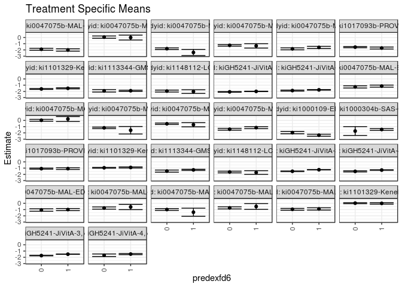

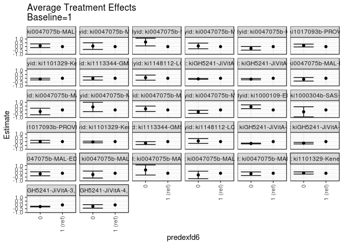

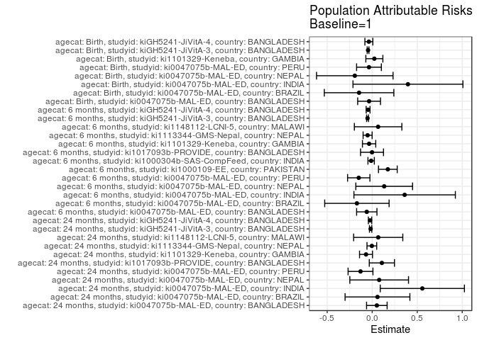

## Results Table

### Parameter: TSM

| agecat | studyid | country | intervention_level | baseline_level | estimate | ci_lower | ci_upper |
| --- | --- | --- | --- | --- | --- | --- | --- |
| Birth | ki0047075b-MAL-ED | BANGLADESH | 1 | NA | -0.9969748 | -1.1688007 | -0.8251488 |
| Birth | ki0047075b-MAL-ED | BANGLADESH | 0 | NA | -1.0686607 | -1.2652159 | -0.8721056 |
| Birth | ki0047075b-MAL-ED | BRAZIL | 1 | NA | -0.5803704 | -1.0024088 | -0.1583320 |
| Birth | ki0047075b-MAL-ED | BRAZIL | 0 | NA | -0.7529730 | -0.9271183 | -0.5788277 |
| Birth | ki0047075b-MAL-ED | INDIA | 1 | NA | -1.4220000 | -2.0676048 | -0.7763952 |
| Birth | ki0047075b-MAL-ED | INDIA | 0 | NA | -0.9910286 | -1.1400640 | -0.8419932 |
| Birth | ki0047075b-MAL-ED | NEPAL | 1 | NA | -0.5030435 | -0.9644424 | -0.0416445 |
| Birth | ki0047075b-MAL-ED | NEPAL | 0 | NA | -0.7267347 | -0.8950835 | -0.5583859 |
| Birth | ki0047075b-MAL-ED | PERU | 1 | NA | -0.8952830 | -1.0781427 | -0.7124233 |
| Birth | ki0047075b-MAL-ED | PERU | 0 | NA | -0.9565333 | -1.1035020 | -0.8095647 |
| Birth | ki1101329-Keneba | GAMBIA | 1 | NA | -0.0076446 | -0.1260217 | 0.1107325 |
| Birth | ki1101329-Keneba | GAMBIA | 0 | NA | 0.0287895 | -0.0541399 | 0.1117190 |
| Birth | kiGH5241-JiVitA-3 | BANGLADESH | 1 | NA | -1.5043389 | -1.5249862 | -1.4836916 |
| Birth | kiGH5241-JiVitA-3 | BANGLADESH | 0 | NA | -1.7243251 | -1.7665982 | -1.6820521 |
| Birth | kiGH5241-JiVitA-4 | BANGLADESH | 1 | NA | -1.4834733 | -1.5751679 | -1.3917788 |
| Birth | kiGH5241-JiVitA-4 | BANGLADESH | 0 | NA | -1.6766216 | -1.8865755 | -1.4666677 |
| 6 months | ki0047075b-MAL-ED | BANGLADESH | 1 | NA | -1.1537127 | -1.3124859 | -0.9949396 |
| 6 months | ki0047075b-MAL-ED | BANGLADESH | 0 | NA | -1.2802827 | -1.4552285 | -1.1053370 |
| 6 months | ki0047075b-MAL-ED | BRAZIL | 1 | NA | 0.2210000 | -0.1803719 | 0.6223719 |
| 6 months | ki0047075b-MAL-ED | BRAZIL | 0 | NA | 0.0168295 | -0.1356848 | 0.1693438 |
| 6 months | ki0047075b-MAL-ED | INDIA | 1 | NA | -1.5796296 | -2.1785068 | -0.9807524 |
| 6 months | ki0047075b-MAL-ED | INDIA | 0 | NA | -1.1890576 | -1.3077211 | -1.0703942 |
| 6 months | ki0047075b-MAL-ED | NEPAL | 1 | NA | -0.6925862 | -1.0314932 | -0.3536792 |
| 6 months | ki0047075b-MAL-ED | NEPAL | 0 | NA | -0.5408495 | -0.6605963 | -0.4211027 |
| 6 months | ki0047075b-MAL-ED | PERU | 1 | NA | -1.1597788 | -1.3156979 | -1.0038596 |
| 6 months | ki0047075b-MAL-ED | PERU | 0 | NA | -1.4176068 | -1.5616997 | -1.2735140 |
| 6 months | ki1000109-EE | PAKISTAN | 1 | NA | -2.3741284 | -2.5321982 | -2.2160586 |
| 6 months | ki1000109-EE | PAKISTAN | 0 | NA | -1.9546429 | -2.1431623 | -1.7661234 |
| 6 months | ki1000304b-SAS-CompFeed | INDIA | 1 | NA | -1.4578628 | -1.6049871 | -1.3107385 |
| 6 months | ki1000304b-SAS-CompFeed | INDIA | 0 | NA | -1.7063158 | -2.4149433 | -0.9976883 |
| 6 months | ki1017093b-PROVIDE | BANGLADESH | 1 | NA | -1.0850735 | -1.2247339 | -0.9454131 |
| 6 months | ki1017093b-PROVIDE | BANGLADESH | 0 | NA | -1.0877218 | -1.1779242 | -0.9975195 |
| 6 months | ki1101329-Keneba | GAMBIA | 1 | NA | -0.8984747 | -0.9872128 | -0.8097366 |
| 6 months | ki1101329-Keneba | GAMBIA | 0 | NA | -0.9484639 | -1.0075750 | -0.8893528 |
| 6 months | ki1113344-GMS-Nepal | NEPAL | 1 | NA | -1.2841089 | -1.3730507 | -1.1951671 |
| 6 months | ki1113344-GMS-Nepal | NEPAL | 0 | NA | -1.4805751 | -1.6493359 | -1.3118144 |
| 6 months | ki1148112-LCNI-5 | MALAWI | 1 | NA | -1.7051064 | -1.9955729 | -1.4146399 |
| 6 months | ki1148112-LCNI-5 | MALAWI | 0 | NA | -1.6259111 | -1.7571663 | -1.4946560 |
| 6 months | kiGH5241-JiVitA-3 | BANGLADESH | 1 | NA | -1.2585797 | -1.2835282 | -1.2336312 |
| 6 months | kiGH5241-JiVitA-3 | BANGLADESH | 0 | NA | -1.5086904 | -1.5557659 | -1.4616149 |
| 6 months | kiGH5241-JiVitA-4 | BANGLADESH | 1 | NA | -1.3116597 | -1.3533383 | -1.2699810 |
| 6 months | kiGH5241-JiVitA-4 | BANGLADESH | 0 | NA | -1.5221629 | -1.6145454 | -1.4297804 |
| 24 months | ki0047075b-MAL-ED | BANGLADESH | 1 | NA | -2.0047768 | -2.1928467 | -1.8167069 |
| 24 months | ki0047075b-MAL-ED | BANGLADESH | 0 | NA | -1.8938144 | -2.0517492 | -1.7358796 |
| 24 months | ki0047075b-MAL-ED | BRAZIL | 1 | NA | -0.0167241 | -0.4098705 | 0.3764223 |
| 24 months | ki0047075b-MAL-ED | BRAZIL | 0 | NA | 0.0539643 | -0.1306705 | 0.2385990 |
| 24 months | ki0047075b-MAL-ED | INDIA | 1 | NA | -2.4032353 | -2.8917688 | -1.9147018 |
| 24 months | ki0047075b-MAL-ED | INDIA | 0 | NA | -1.8008937 | -1.9304012 | -1.6713862 |
| 24 months | ki0047075b-MAL-ED | NEPAL | 1 | NA | -1.3517857 | -1.7006278 | -1.0029436 |
| 24 months | ki0047075b-MAL-ED | NEPAL | 0 | NA | -1.2635678 | -1.3922304 | -1.1349052 |
| 24 months | ki0047075b-MAL-ED | PERU | 1 | NA | -1.5996429 | -1.7777333 | -1.4215524 |
| 24 months | ki0047075b-MAL-ED | PERU | 0 | NA | -1.8251754 | -1.9834123 | -1.6669386 |
| 24 months | ki1017093b-PROVIDE | BANGLADESH | 1 | NA | -1.6934028 | -1.8521533 | -1.5346523 |
| 24 months | ki1017093b-PROVIDE | BANGLADESH | 0 | NA | -1.5504388 | -1.6477726 | -1.4531050 |
| 24 months | ki1101329-Keneba | GAMBIA | 1 | NA | -1.5033612 | -1.5893688 | -1.4173535 |
| 24 months | ki1101329-Keneba | GAMBIA | 0 | NA | -1.6075785 | -1.6745752 | -1.5405818 |
| 24 months | ki1113344-GMS-Nepal | NEPAL | 1 | NA | -1.8910000 | -1.9856651 | -1.7963349 |
| 24 months | ki1113344-GMS-Nepal | NEPAL | 0 | NA | -1.9075556 | -2.1012913 | -1.7138198 |
| 24 months | ki1148112-LCNI-5 | MALAWI | 1 | NA | -2.0273529 | -2.3204751 | -1.7342307 |
| 24 months | ki1148112-LCNI-5 | MALAWI | 0 | NA | -1.9459355 | -2.1034386 | -1.7884323 |
| 24 months | kiGH5241-JiVitA-3 | BANGLADESH | 1 | NA | -1.9946668 | -2.0243233 | -1.9650102 |
| 24 months | kiGH5241-JiVitA-3 | BANGLADESH | 0 | NA | -2.0750134 | -2.1308135 | -2.0192133 |
| 24 months | kiGH5241-JiVitA-4 | BANGLADESH | 1 | NA | -1.7522621 | -1.7943562 | -1.7101679 |
| 24 months | kiGH5241-JiVitA-4 | BANGLADESH | 0 | NA | -1.8651638 | -1.9467717 | -1.7835559 |

### Parameter: E(Y)

| agecat | studyid | country | intervention_level | baseline_level | estimate | ci_lower | ci_upper |
| --- | --- | --- | --- | --- | --- | --- | --- |
| Birth | ki0047075b-MAL-ED | BANGLADESH | NA | NA | -1.0317316 | -1.1618799 | -0.9015833 |
| Birth | ki0047075b-MAL-ED | BRAZIL | NA | NA | -0.7263429 | -0.8876385 | -0.5650472 |
| Birth | ki0047075b-MAL-ED | INDIA | NA | NA | -1.0250526 | -1.1724135 | -0.8776918 |
| Birth | ki0047075b-MAL-ED | NEPAL | NA | NA | -0.6964706 | -0.8552823 | -0.5376589 |
| Birth | ki0047075b-MAL-ED | PERU | NA | NA | -0.9311719 | -1.0458986 | -0.8164451 |
| Birth | ki1101329-Keneba | GAMBIA | NA | NA | 0.0162027 | -0.0517648 | 0.0841702 |
| Birth | kiGH5241-JiVitA-3 | BANGLADESH | NA | NA | -1.5502914 | -1.5696478 | -1.5309349 |
| Birth | kiGH5241-JiVitA-4 | BANGLADESH | NA | NA | -1.5207432 | -1.6058630 | -1.4356233 |
| 6 months | ki0047075b-MAL-ED | BANGLADESH | NA | NA | -1.2140355 | -1.3320337 | -1.0960372 |
| 6 months | ki0047075b-MAL-ED | BRAZIL | NA | NA | 0.0510207 | -0.0930194 | 0.1950608 |
| 6 months | ki0047075b-MAL-ED | INDIA | NA | NA | -1.2193606 | -1.3390323 | -1.0996890 |
| 6 months | ki0047075b-MAL-ED | NEPAL | NA | NA | -0.5595745 | -0.6727496 | -0.4463993 |
| 6 months | ki0047075b-MAL-ED | PERU | NA | NA | -1.3092999 | -1.4165606 | -1.2020392 |
| 6 months | ki1000109-EE | PAKISTAN | NA | NA | -2.2004704 | -2.3234073 | -2.0775336 |
| 6 months | ki1000304b-SAS-CompFeed | INDIA | NA | NA | -1.4697236 | -1.6333919 | -1.3060553 |
| 6 months | ki1017093b-PROVIDE | BANGLADESH | NA | NA | -1.0871041 | -1.1635539 | -1.0106543 |
| 6 months | ki1101329-Keneba | GAMBIA | NA | NA | -0.9331108 | -0.9823173 | -0.8839043 |
| 6 months | ki1113344-GMS-Nepal | NEPAL | NA | NA | -1.3352045 | -1.4146382 | -1.2557708 |
| 6 months | ki1148112-LCNI-5 | MALAWI | NA | NA | -1.6395956 | -1.7592633 | -1.5199278 |
| 6 months | kiGH5241-JiVitA-3 | BANGLADESH | NA | NA | -1.3104400 | -1.3338132 | -1.2870668 |
| 6 months | kiGH5241-JiVitA-4 | BANGLADESH | NA | NA | -1.3574771 | -1.3964060 | -1.3185482 |
| 24 months | ki0047075b-MAL-ED | BANGLADESH | NA | NA | -1.9532775 | -2.0781247 | -1.8284303 |
| 24 months | ki0047075b-MAL-ED | BRAZIL | NA | NA | 0.0418343 | -0.1253834 | 0.2090521 |
| 24 months | ki0047075b-MAL-ED | INDIA | NA | NA | -1.8466071 | -1.9736347 | -1.7195796 |
| 24 months | ki0047075b-MAL-ED | NEPAL | NA | NA | -1.2744493 | -1.3952297 | -1.1536689 |
| 24 months | ki0047075b-MAL-ED | PERU | NA | NA | -1.7294949 | -1.8488722 | -1.6101177 |
| 24 months | ki1017093b-PROVIDE | BANGLADESH | NA | NA | -1.5861179 | -1.6693668 | -1.5028689 |
| 24 months | ki1101329-Keneba | GAMBIA | NA | NA | -1.5721046 | -1.6251725 | -1.5190368 |
| 24 months | ki1113344-GMS-Nepal | NEPAL | NA | NA | -1.8951389 | -1.9810871 | -1.8091907 |
| 24 months | ki1148112-LCNI-5 | MALAWI | NA | NA | -1.9605820 | -2.1001715 | -1.8209925 |
| 24 months | kiGH5241-JiVitA-3 | BANGLADESH | NA | NA | -2.0122091 | -2.0399540 | -1.9844641 |
| 24 months | kiGH5241-JiVitA-4 | BANGLADESH | NA | NA | -1.7762003 | -1.8148628 | -1.7375378 |

### Parameter: ATE

| agecat | studyid | country | intervention_level | baseline_level | estimate | ci_lower | ci_upper |
| --- | --- | --- | --- | --- | --- | --- | --- |
| Birth | ki0047075b-MAL-ED | BANGLADESH | 1 | 1 | 0.0000000 | 0.0000000 | 0.0000000 |
| Birth | ki0047075b-MAL-ED | BANGLADESH | 0 | 1 | -0.0716859 | -0.3327570 | 0.1893851 |
| Birth | ki0047075b-MAL-ED | BRAZIL | 1 | 1 | 0.0000000 | 0.0000000 | 0.0000000 |
| Birth | ki0047075b-MAL-ED | BRAZIL | 0 | 1 | -0.1726026 | -0.6291582 | 0.2839530 |
| Birth | ki0047075b-MAL-ED | INDIA | 1 | 1 | 0.0000000 | 0.0000000 | 0.0000000 |
| Birth | ki0047075b-MAL-ED | INDIA | 0 | 1 | 0.4309714 | -0.2316123 | 1.0935551 |
| Birth | ki0047075b-MAL-ED | NEPAL | 1 | 1 | 0.0000000 | 0.0000000 | 0.0000000 |
| Birth | ki0047075b-MAL-ED | NEPAL | 0 | 1 | -0.2236912 | -0.7148432 | 0.2674608 |
| Birth | ki0047075b-MAL-ED | PERU | 1 | 1 | 0.0000000 | 0.0000000 | 0.0000000 |
| Birth | ki0047075b-MAL-ED | PERU | 0 | 1 | -0.0612503 | -0.2958510 | 0.1733503 |
| Birth | ki1101329-Keneba | GAMBIA | 1 | 1 | 0.0000000 | 0.0000000 | 0.0000000 |
| Birth | ki1101329-Keneba | GAMBIA | 0 | 1 | 0.0364342 | -0.1081011 | 0.1809694 |
| Birth | kiGH5241-JiVitA-3 | BANGLADESH | 1 | 1 | 0.0000000 | 0.0000000 | 0.0000000 |
| Birth | kiGH5241-JiVitA-3 | BANGLADESH | 0 | 1 | -0.2199862 | -0.2651736 | -0.1747989 |
| Birth | kiGH5241-JiVitA-4 | BANGLADESH | 1 | 1 | 0.0000000 | 0.0000000 | 0.0000000 |
| Birth | kiGH5241-JiVitA-4 | BANGLADESH | 0 | 1 | -0.1931483 | -0.4209843 | 0.0346878 |
| 6 months | ki0047075b-MAL-ED | BANGLADESH | 1 | 1 | 0.0000000 | 0.0000000 | 0.0000000 |
| 6 months | ki0047075b-MAL-ED | BANGLADESH | 0 | 1 | -0.1265700 | -0.3628218 | 0.1096818 |
| 6 months | ki0047075b-MAL-ED | BRAZIL | 1 | 1 | 0.0000000 | 0.0000000 | 0.0000000 |
| 6 months | ki0047075b-MAL-ED | BRAZIL | 0 | 1 | -0.2041705 | -0.6335421 | 0.2252011 |
| 6 months | ki0047075b-MAL-ED | INDIA | 1 | 1 | 0.0000000 | 0.0000000 | 0.0000000 |
| 6 months | ki0047075b-MAL-ED | INDIA | 0 | 1 | 0.3905720 | -0.2199482 | 1.0010922 |
| 6 months | ki0047075b-MAL-ED | NEPAL | 1 | 1 | 0.0000000 | 0.0000000 | 0.0000000 |
| 6 months | ki0047075b-MAL-ED | NEPAL | 0 | 1 | 0.1517367 | -0.2077035 | 0.5111769 |
| 6 months | ki0047075b-MAL-ED | PERU | 1 | 1 | 0.0000000 | 0.0000000 | 0.0000000 |
| 6 months | ki0047075b-MAL-ED | PERU | 0 | 1 | -0.2578281 | -0.4701333 | -0.0455228 |
| 6 months | ki1000109-EE | PAKISTAN | 1 | 1 | 0.0000000 | 0.0000000 | 0.0000000 |
| 6 months | ki1000109-EE | PAKISTAN | 0 | 1 | 0.4194856 | 0.1734660 | 0.6655052 |
| 6 months | ki1000304b-SAS-CompFeed | INDIA | 1 | 1 | 0.0000000 | 0.0000000 | 0.0000000 |
| 6 months | ki1000304b-SAS-CompFeed | INDIA | 0 | 1 | -0.2484530 | -0.9061015 | 0.4091955 |
| 6 months | ki1017093b-PROVIDE | BANGLADESH | 1 | 1 | 0.0000000 | 0.0000000 | 0.0000000 |
| 6 months | ki1017093b-PROVIDE | BANGLADESH | 0 | 1 | -0.0026483 | -0.1689056 | 0.1636090 |
| 6 months | ki1101329-Keneba | GAMBIA | 1 | 1 | 0.0000000 | 0.0000000 | 0.0000000 |
| 6 months | ki1101329-Keneba | GAMBIA | 0 | 1 | -0.0499892 | -0.1566127 | 0.0566343 |
| 6 months | ki1113344-GMS-Nepal | NEPAL | 1 | 1 | 0.0000000 | 0.0000000 | 0.0000000 |
| 6 months | ki1113344-GMS-Nepal | NEPAL | 0 | 1 | -0.1964662 | -0.3872300 | -0.0057024 |
| 6 months | ki1148112-LCNI-5 | MALAWI | 1 | 1 | 0.0000000 | 0.0000000 | 0.0000000 |
| 6 months | ki1148112-LCNI-5 | MALAWI | 0 | 1 | 0.0791953 | -0.2395502 | 0.3979408 |
| 6 months | kiGH5241-JiVitA-3 | BANGLADESH | 1 | 1 | 0.0000000 | 0.0000000 | 0.0000000 |
| 6 months | kiGH5241-JiVitA-3 | BANGLADESH | 0 | 1 | -0.2501106 | -0.2994716 | -0.2007497 |
| 6 months | kiGH5241-JiVitA-4 | BANGLADESH | 1 | 1 | 0.0000000 | 0.0000000 | 0.0000000 |
| 6 months | kiGH5241-JiVitA-4 | BANGLADESH | 0 | 1 | -0.2105032 | -0.3102246 | -0.1107819 |
| 24 months | ki0047075b-MAL-ED | BANGLADESH | 1 | 1 | 0.0000000 | 0.0000000 | 0.0000000 |
| 24 months | ki0047075b-MAL-ED | BANGLADESH | 0 | 1 | 0.1109624 | -0.1346261 | 0.3565508 |
| 24 months | ki0047075b-MAL-ED | BRAZIL | 1 | 1 | 0.0000000 | 0.0000000 | 0.0000000 |
| 24 months | ki0047075b-MAL-ED | BRAZIL | 0 | 1 | 0.0706884 | -0.3636549 | 0.5050317 |
| 24 months | ki0047075b-MAL-ED | INDIA | 1 | 1 | 0.0000000 | 0.0000000 | 0.0000000 |
| 24 months | ki0047075b-MAL-ED | INDIA | 0 | 1 | 0.6023416 | 0.0969336 | 1.1077495 |
| 24 months | ki0047075b-MAL-ED | NEPAL | 1 | 1 | 0.0000000 | 0.0000000 | 0.0000000 |
| 24 months | ki0047075b-MAL-ED | NEPAL | 0 | 1 | 0.0882179 | -0.2835951 | 0.4600308 |
| 24 months | ki0047075b-MAL-ED | PERU | 1 | 1 | 0.0000000 | 0.0000000 | 0.0000000 |
| 24 months | ki0047075b-MAL-ED | PERU | 0 | 1 | -0.2255326 | -0.4637659 | 0.0127007 |
| 24 months | ki1017093b-PROVIDE | BANGLADESH | 1 | 1 | 0.0000000 | 0.0000000 | 0.0000000 |
| 24 months | ki1017093b-PROVIDE | BANGLADESH | 0 | 1 | 0.1429640 | -0.0432499 | 0.3291778 |
| 24 months | ki1101329-Keneba | GAMBIA | 1 | 1 | 0.0000000 | 0.0000000 | 0.0000000 |
| 24 months | ki1101329-Keneba | GAMBIA | 0 | 1 | -0.1042173 | -0.2132397 | 0.0048050 |
| 24 months | ki1113344-GMS-Nepal | NEPAL | 1 | 1 | 0.0000000 | 0.0000000 | 0.0000000 |
| 24 months | ki1113344-GMS-Nepal | NEPAL | 0 | 1 | -0.0165556 | -0.2321826 | 0.1990715 |
| 24 months | ki1148112-LCNI-5 | MALAWI | 1 | 1 | 0.0000000 | 0.0000000 | 0.0000000 |
| 24 months | ki1148112-LCNI-5 | MALAWI | 0 | 1 | 0.0814175 | -0.2513405 | 0.4141754 |
| 24 months | kiGH5241-JiVitA-3 | BANGLADESH | 1 | 1 | 0.0000000 | 0.0000000 | 0.0000000 |
| 24 months | kiGH5241-JiVitA-3 | BANGLADESH | 0 | 1 | -0.0803466 | -0.1393225 | -0.0213707 |
| 24 months | kiGH5241-JiVitA-4 | BANGLADESH | 1 | 1 | 0.0000000 | 0.0000000 | 0.0000000 |
| 24 months | kiGH5241-JiVitA-4 | BANGLADESH | 0 | 1 | -0.1129018 | -0.2015013 | -0.0243022 |

### Parameter: PAR

| agecat | studyid | country | intervention_level | baseline_level | estimate | ci_lower | ci_upper |
| --- | --- | --- | --- | --- | --- | --- | --- |
| Birth | ki0047075b-MAL-ED | BANGLADESH | 1 | NA | -0.0347568 | -0.1614214 | 0.0919077 |
| Birth | ki0047075b-MAL-ED | BRAZIL | 1 | NA | -0.1459725 | -0.5321992 | 0.2402542 |
| Birth | ki0047075b-MAL-ED | INDIA | 1 | NA | 0.3969474 | -0.2135520 | 1.0074467 |
| Birth | ki0047075b-MAL-ED | NEPAL | 1 | NA | -0.1934271 | -0.6182858 | 0.2314316 |
| Birth | ki0047075b-MAL-ED | PERU | 1 | NA | -0.0358889 | -0.1734000 | 0.1016223 |
| Birth | ki1101329-Keneba | GAMBIA | 1 | NA | 0.0238473 | -0.0707600 | 0.1184547 |
| Birth | kiGH5241-JiVitA-3 | BANGLADESH | 1 | NA | -0.0459525 | -0.0554910 | -0.0364139 |
| Birth | kiGH5241-JiVitA-4 | BANGLADESH | 1 | NA | -0.0372698 | -0.0814379 | 0.0068983 |
| 6 months | ki0047075b-MAL-ED | BANGLADESH | 1 | NA | -0.0603227 | -0.1732103 | 0.0525648 |
| 6 months | ki0047075b-MAL-ED | BRAZIL | 1 | NA | -0.1699793 | -0.5275967 | 0.1876381 |
| 6 months | ki0047075b-MAL-ED | INDIA | 1 | NA | 0.3602690 | -0.2030444 | 0.9235824 |
| 6 months | ki0047075b-MAL-ED | NEPAL | 1 | NA | 0.1330117 | -0.1821369 | 0.4481603 |
| 6 months | ki0047075b-MAL-ED | PERU | 1 | NA | -0.1495211 | -0.2735815 | -0.0254608 |
| 6 months | ki1000109-EE | PAKISTAN | 1 | NA | 0.1736580 | 0.0696638 | 0.2776522 |
| 6 months | ki1000304b-SAS-CompFeed | INDIA | 1 | NA | -0.0118608 | -0.0472806 | 0.0235590 |
| 6 months | ki1017093b-PROVIDE | BANGLADESH | 1 | NA | -0.0020305 | -0.1295040 | 0.1254429 |
| 6 months | ki1101329-Keneba | GAMBIA | 1 | NA | -0.0346361 | -0.1085198 | 0.0392476 |
| 6 months | ki1113344-GMS-Nepal | NEPAL | 1 | NA | -0.0510956 | -0.1012330 | -0.0009582 |
| 6 months | ki1148112-LCNI-5 | MALAWI | 1 | NA | 0.0655108 | -0.1981815 | 0.3292031 |
| 6 months | kiGH5241-JiVitA-3 | BANGLADESH | 1 | NA | -0.0518602 | -0.0621131 | -0.0416074 |
| 6 months | kiGH5241-JiVitA-4 | BANGLADESH | 1 | NA | -0.0458174 | -0.0671497 | -0.0244852 |
| 24 months | ki0047075b-MAL-ED | BANGLADESH | 1 | NA | 0.0514993 | -0.0627298 | 0.1657283 |
| 24 months | ki0047075b-MAL-ED | BRAZIL | 1 | NA | 0.0585585 | -0.3012751 | 0.4183920 |
| 24 months | ki0047075b-MAL-ED | INDIA | 1 | NA | 0.5566282 | 0.0891081 | 1.0241482 |
| 24 months | ki0047075b-MAL-ED | NEPAL | 1 | NA | 0.0773364 | -0.2486361 | 0.4033089 |
| 24 months | ki0047075b-MAL-ED | PERU | 1 | NA | -0.1298521 | -0.2678970 | 0.0081929 |
| 24 months | ki1017093b-PROVIDE | BANGLADESH | 1 | NA | 0.1072849 | -0.0325474 | 0.2471173 |
| 24 months | ki1101329-Keneba | GAMBIA | 1 | NA | -0.0687435 | -0.1406995 | 0.0032125 |
| 24 months | ki1113344-GMS-Nepal | NEPAL | 1 | NA | -0.0041389 | -0.0580495 | 0.0497717 |
| 24 months | ki1148112-LCNI-5 | MALAWI | 1 | NA | 0.0667709 | -0.2061624 | 0.3397043 |
| 24 months | kiGH5241-JiVitA-3 | BANGLADESH | 1 | NA | -0.0175423 | -0.0303794 | -0.0047052 |
| 24 months | kiGH5241-JiVitA-4 | BANGLADESH | 1 | NA | -0.0239382 | -0.0424975 | -0.0053789 |